# 17_cross_validation_results

## Cross-validation procedure

Let $\mathbb{K}$ denote the set of kernel functions and $\mathcal{B}(K)$ the set of bandwidth selection procedures available for kernel $K$. In addition, let $\mathbb{P}$ denote the set of post-processing configurations. Each $P \in \mathbb{P}$ specifies a rule for computing a local mean of the density curves and is defined by a mean-computation mode and an associated window length $w$. In the empirical application, the mean-computation mode may correspond to an expanding or rolling scheme, while the window length determines the number of past curves used in the computation. The set $\mathbb{P}$ also includes the configuration corresponding to no post-processing, for which the transformation operator reduces to the identity mapping $\mathcal{T}_{P}(f_t)=f_t$.

The complete parameter space is defined as \begin{equation} \Theta = \{(K, B, \eta, P) : K \in \mathbb{K},\; B \in \mathcal{B}(K),\; P \in \mathbb{P}\}, \end{equation} where $\eta$ captures auxiliary parameters, such as the degrees of freedom for the Student-t kernel or the robust scale estimator for Silverman’s rule. In the present setting, these correspond to the degrees of freedom parameter for the Student-$t$ kernel or the use of a robust standard deviation estimator in the Silverman bandwidth rule. Each configuration $\theta_j \in \Theta$ is therefore defined as \begin{equation} \theta_j = (K_j, B_j, \eta_j, P_j), \quad j = 1,\dots,M. \end{equation}

Let $r_{t1},\dots,r_{tn_t}$ denote the intraday log-returns observed on day $t$, for $t=1,\dots,T$. For a given configuration $(K_j,B_j,\eta_j)$, the raw daily density estimates are first obtained using the kernel density estimator

\begin{equation} f_t^{(K_j,B_j,\eta_j)}(x) = \frac{1}{n_t h_t^{(j)}} \sum_{i=1}^{n_t} K_j\!\left(\frac{r_{ti}-x}{h_t^{(j)}};\eta_j\right), \end{equation}

where $h_t^{(j)}$ is the bandwidth determined by the rule $B_j$. This produces the functional time series of densities \begin{equation} \mathcal{X}^{(K_j,B_j,\eta_j)}=\{f_1^{(K_j,B_j,\eta_j)},\dots,f_T^{(K_j,B_j,\eta_j)}\}. \end{equation}

The post-processing configuration $P_j$ is then applied through a transformation operator $\mathcal{T}_{P_j}$ acting on the sequence of density curves. This yields the transformed functional time series \begin{align*} \mathcal{Z}^{(\theta_j)} &= \{Z_1^{(\theta_j)},\dots,Z_T^{(\theta_j)}\}, \\ Z_t^{(\theta_j)} &= \big(\mathcal{T}_{P_j}(\mathcal{X}^{(K_j,B_j,\eta_j)})\big)_t. \end{align*}

The sample is partitioned into three segments: an initial estimation period, a validation period, and a test period. Let $t_0$ denote the size of the initial estimation window and let $t_v$ denote the final index of the validation period, where $t_0 < t_v < T$. The observations $t=1,\dots,t_0$ form the initial estimation sample. Forecasts corresponding to $t=t_0+1,\dots,t_v$ constitute the validation period used for model selection, while forecasts for $t=t_v+1,\dots,T$ form the test period used for final forecast evaluation. For each configuration $\theta_i$, forecasts are generated using an expanding window scheme. At each step $t=t_0,\dots,T-1$, the forecasting model is estimated using the sample ${Z_1^{(\theta_i)},\dots,Z_t^{(\theta_i)}}$ and produces a one-step-ahead forecast $\widehat{Z}_{t+1}^{(\theta_i)}$. This procedure yields the sequence $ \widehat{Z}_{t_0+1}^{(\theta_i)},\widehat{Z}_{t_0+2}^{(\theta_i)},\dots, \widehat{Z}_{T}^{(\theta_i)}. $ In the empirical application considered in this dissertation, the initial estimation window is set to $t_0=100$, and the validation period ends at $t_v=180$. Consequently, the validation and test partitions contain 80 and 67 evaluation curves, respectively.

\begin{equation} L_{ij} = \frac{1}{t_v - t_0} \sum_{t=t_0}^{t_v-1} D\!\left( Z_{t+1}^{(\theta_j)}, \widehat{Z}_{t+1}^{(\theta_i)} \right). \end{equation}

which yields an $M \times M$ loss matrix. Finally, the selected configuration is

\begin{equation*} \theta^* = \arg\min_{\theta_i \in \Theta} \frac{1}{M} \sum_{j=1}^{M} L_{ij}. \end{equation*}

In out configuration, M = 53.

```python
import pandas as pd

import matplotlib.pyplot as plt
import seaborn as sns
import plotly.express as px

import joblib
```

```python
df_cv = joblib.load('../data/processed/cv_divergences_long_20260316.jbl')
df_cv["forecast_kde_pp_params"] = df_cv["forecast_kde_params"] + "___" + df_cv["forecast_pp_params"]
display(df_cv.head())
df_cv.shape
```

|  | kde_model | forecast_model | forecast_kde_params | forecast_pp_params | forecast_dFPC_dimension | forecast_VAR_q | date | KLD | JSD | L1_norm | L2_norm | LINF_norm | forecast_kde_pp_params |
| --- | --- | --- | --- | --- | --- | --- | --- | --- | --- | --- | --- | --- | --- |
| 0 | gaussian_rot_robust___False | gaussian_adaptive___rolling_w21___4___1 | gaussian_adaptive | rolling_w21 | 4 | 1 | 2025-05-05 | 4.463318 | 0.259433 | 132390.399380 | 9300.290670 | 1423.011034 | gaussian_adaptive___rolling_w21 |
| 1 | gaussian_rot_robust___False | gaussian_adaptive___rolling_w21___4___1 | gaussian_adaptive | rolling_w21 | 4 | 1 | 2025-05-06 | 4.747499 | 0.286736 | 136876.520476 | 9607.463644 | 1460.064834 | gaussian_adaptive___rolling_w21 |
| 2 | gaussian_rot_robust___False | gaussian_adaptive___rolling_w21___4___1 | gaussian_adaptive | rolling_w21 | 4 | 1 | 2025-05-07 | 4.524809 | 0.260094 | 128365.689601 | 8981.680620 | 1361.856441 | gaussian_adaptive___rolling_w21 |
| 3 | gaussian_rot_robust___False | gaussian_adaptive___rolling_w21___4___1 | gaussian_adaptive | rolling_w21 | 4 | 1 | 2025-05-08 | 6.517256 | 0.328244 | 153828.869188 | 10192.001729 | 1560.988364 | gaussian_adaptive___rolling_w21 |
| 4 | gaussian_rot_robust___False | gaussian_adaptive___rolling_w21___4___1 | gaussian_adaptive | rolling_w21 | 4 | 1 | 2025-05-09 | 3.072839 | 0.173923 | 101820.998518 | 7167.118634 | 1072.201651 | gaussian_adaptive___rolling_w21 |

```
(5580900, 13)
```

- kde_model: the database $\theta_j$
- forecast_kde_pp_params: kernel, bandwidth and postprocessing params for forecasting with $\theta_i$
- KLD, JSD, L-norms = $D(\theta_{tj}, \theta_{ti})$

```python
# Top models by kernel + bandwidth selection method
df_cv.groupby("forecast_kde_params")["KLD"].mean().sort_values()
```

```
forecast_kde_params
epanechnikov_adaptive                1.279110
gaussian_adaptive                    1.434770
epanechnikov_rot_robust              1.492843
epanechnikov_rot                     1.619572
t-student_cross_validate_df=5_loo    1.683783
t-student_cross_validate_df=4_loo    1.689085
t-student_cross_validate_df=3_loo    1.705115
gaussian_cross_validate_loo          1.748596
t-student_adaptive_df=5              1.764021
t-student_adaptive_df=4              1.764443
t-student_adaptive_df=3              1.767298
gaussian_rot                         1.804581
gaussian_rot_robust                  1.959726
Name: KLD, dtype: float64
```

```python
# Top models by postprocessing method
df_cv.groupby("forecast_pp_params")["KLD"].mean().sort_values()
```

```
forecast_pp_params
rolling_w5     0.954687
expanding      1.229258
rolling_w21    1.476562
False          2.484157
rolling_w63    2.751588
Name: KLD, dtype: float64
```

```
forecast_pp_params
```

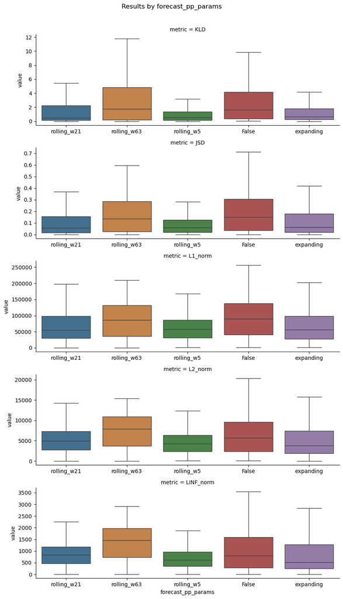

```python
criterion = "forecast_pp_params"

results_by_criterion = df_cv.loc[:, [criterion, 'KLD', 'JSD', 'L1_norm', 'L2_norm', 'LINF_norm']]
rbc_long = results_by_criterion.melt(id_vars=[criterion], var_name="metric")
rbc_long[criterion] = rbc_long.loc[:,criterion].apply(str)

if rbc_long[criterion].nunique() >= len(['KLD', 'JSD', 'L1_norm', 'L2_norm', 'LINF_norm']):
    columns_by = None
    rows_by   = "metric"
    aspect=3
else:
    columns_by = "metric"
    rows_by   =  None
    aspect=1

plt.figure(figsize=(10, 5))

print(criterion)
g = sns.catplot(
    data=rbc_long,
    x=criterion,
    y="value",
    row=rows_by,
    col=columns_by,
    kind="box",
    hue=criterion,
    sharey=False,
    sharex=False,
    height=3,
    aspect=aspect,
    saturation=.5,
    showfliers=False,
)

plt.suptitle(f"Results by {criterion}",y=1.03)

plt.show()
```

```python
# Top models by kernel + bandwidth selection + postprocessing method
df_cv.groupby("forecast_kde_pp_params")["KLD"].mean().sort_values()
```

```
forecast_kde_pp_params
t-student_adaptive_df=3___rolling_w5               0.807961
t-student_cross_validate_df=3_loo___rolling_w5     0.815676
t-student_adaptive_df=4___rolling_w5               0.822652
t-student_cross_validate_df=4_loo___rolling_w5     0.824431
t-student_cross_validate_df=5_loo___rolling_w5     0.829342
t-student_adaptive_df=5___rolling_w5               0.833066
epanechnikov_rot_robust___rolling_w5               0.873882
gaussian_adaptive___rolling_w5                     0.884932
epanechnikov_rot___rolling_w5                      0.885023
epanechnikov_adaptive___expanding                  0.894040
gaussian_adaptive___expanding                      0.949534
epanechnikov_adaptive___rolling_w5                 0.950560
gaussian_cross_validate_loo___rolling_w5           1.022110
t-student_adaptive_df=5___expanding                1.029869
t-student_adaptive_df=4___expanding                1.054301
t-student_adaptive_df=3___expanding                1.092941
t-student_cross_validate_df=3_loo___expanding      1.202743
t-student_cross_validate_df=4_loo___expanding      1.244295
t-student_cross_validate_df=5_loo___expanding      1.270552
t-student_cross_validate_df=5_loo___rolling_w21    1.276975
gaussian_rot___rolling_w5                          1.277398
t-student_cross_validate_df=4_loo___rolling_w21    1.302964
epanechnikov_rot_robust___expanding                1.333550
t-student_cross_validate_df=3_loo___rolling_w21    1.347784
epanechnikov_rot___expanding                       1.454272
gaussian_rot___expanding                           1.481680
gaussian_cross_validate_loo___expanding            1.484345
t-student_adaptive_df=3___rolling_w21              1.490218
gaussian_rot_robust___expanding                    1.517793
t-student_adaptive_df=4___rolling_w21              1.539272
gaussian_cross_validate_loo___rolling_w21          1.552282
t-student_adaptive_df=5___rolling_w21              1.573295
gaussian_rot_robust___rolling_w5                   1.612546
gaussian_adaptive___rolling_w21                    1.730955
epanechnikov_adaptive___False                      1.992731
gaussian_adaptive___False                          2.173658
epanechnikov_rot_robust___False                    2.271096
t-student_adaptive_df=5___False                    2.365093
t-student_adaptive_df=4___False                    2.436068
t-student_cross_validate_df=5_loo___rolling_w63    2.462364
epanechnikov_rot___False                           2.519420
t-student_cross_validate_df=3_loo___False          2.519744
t-student_cross_validate_df=4_loo___rolling_w63    2.521343
t-student_adaptive_df=3___False                    2.547883
t-student_cross_validate_df=4_loo___False          2.552394
t-student_cross_validate_df=5_loo___False          2.579681
t-student_cross_validate_df=3_loo___rolling_w63    2.639628
gaussian_rot___False                               2.656016
gaussian_rot_robust___False                        2.786654
t-student_adaptive_df=3___rolling_w63              2.897485
gaussian_cross_validate_loo___False                2.927924
t-student_adaptive_df=4___rolling_w63              2.969922
t-student_adaptive_df=5___rolling_w63              3.018784
Name: KLD, dtype: float64
```

```python
# Top models by kernel + bandwidth selection + postprocessing + dimensions + VAR(q) method
df_cv.groupby("forecast_model")["KLD"].mean().sort_values()
```

```
forecast_model
t-student_adaptive_df=3___rolling_w5___4___4    0.805081
t-student_adaptive_df=3___rolling_w5___5___4    0.805283
t-student_adaptive_df=3___rolling_w5___3___4    0.805368
t-student_adaptive_df=3___rolling_w5___2___4    0.805899
t-student_adaptive_df=3___rolling_w5___3___2    0.805987
                                                  ...
gaussian_rot_robust___False___6___3             3.132552
gaussian_rot_robust___False___5___2             3.145348
gaussian_rot_robust___False___6___4             3.391092
gaussian_rot_robust___False___5___4             3.471076
gaussian_rot_robust___False___6___2             3.591010
Name: KLD, Length: 1060, dtype: float64
```